# Debuts GLM

2025-07-10

#### 1 Mise en place

```r
source("~/work/AnalyseDonneesOpportunisteGMB/00_Nouveau/src/functions/divers.R")
wd <- set_wd()
source(paste0(wd$src, "functions/cartographie.R"))
source(paste0(wd$src, "functions/comparaison_dans_mailles.R"))
source(paste0(wd$src, "functions/GLM.R"))
```

```r
Total <- transform_Total()
Total <- ajout_famille_paysage()
Total <- creer_maille(bdd = Total, taille_en_km = 2)
Total <- creer_maille(bdd = Total, taille_en_km = 5)
Total <- creer_maille(bdd = Total, taille_en_km = 10)
Total <- creer_maille(bdd = Total, taille_en_km = 20)
```

#### 2 Regression proportion de lapin vs chevreuil par 10km^2.

```r
bdd_reg <- tab_glm(espece_interet = 61714,
              espece_benchmark = 61057,
              taillegrid = "Grid10km")
```

Ici on cherche la tendance du Lapin de garenne en prenant le Chevreuil comme espèce de référence. Les sites choisis ici sont des mailles de 10km, dans lequel on calcule la proportion de lapin par rapport au chevreuil au fil des années.

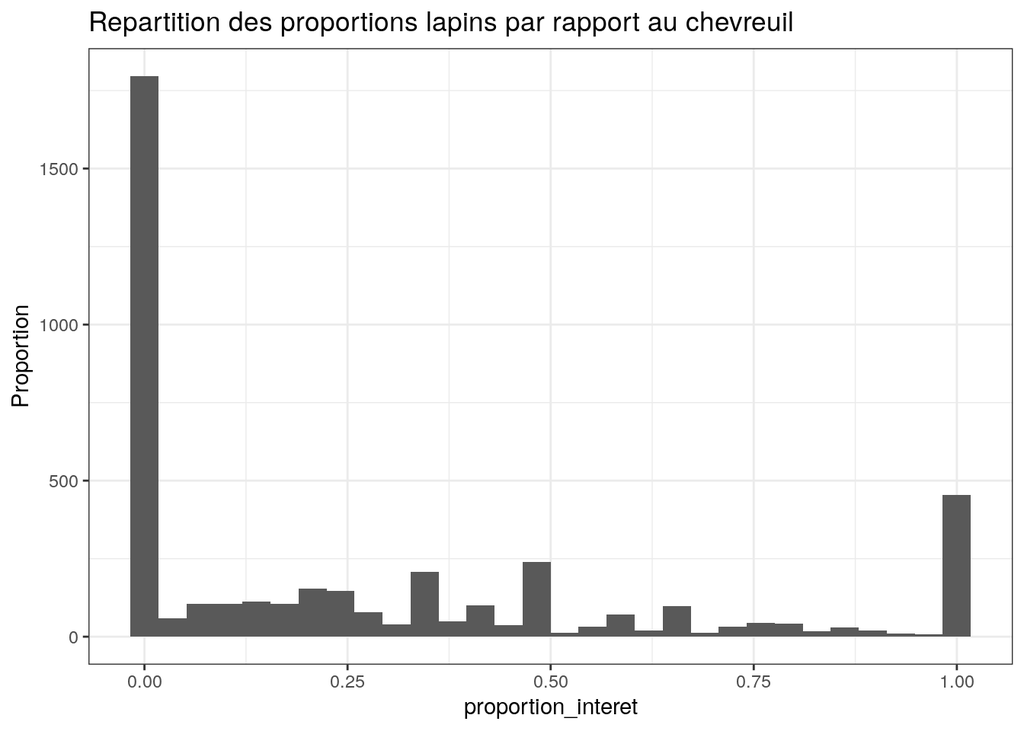

```r
bdd_reg %>%
  ggplot() +
  geom_histogram(aes(proportion_interet)) +
  labs(title = "Repartition des proportions lapins par rapport au chevreuil",
       y = "Proportion") + theme_bw()
```

On remarque qu’il y a une grande partie de zero -> On pourra vouloir utiliser des modèles a inflation 0.

Regarder aussi si les 0 sont sur le même site sur toutes les années -> On pourrait penser les retirer? Ca risque de nous diminuer la tendance potentielle. Une legere inflation en 1 egalement.

Retirer tous les 0 et 1 serait mauvais.

#### 3 Year en variable quantitative discrete:

```r
reg <- glm(data = bdd_reg,
           proportion_interet ~ year)

summary(reg)
```

```
##
## Call:
## glm(formula = proportion_interet ~ year, data = bdd_reg)
##
## Coefficients:
##              Estimate Std. Error t value Pr(>|t|)
## (Intercept) 29.825545   2.294817   13.00   <2e-16 ***
## year        -0.014642   0.001137  -12.87   <2e-16 ***
## ---
## Signif. codes:  0 '***' 0.001 '**' 0.01 '*' 0.05 '.' 0.1 ' ' 1
##
## (Dispersion parameter for gaussian family taken to be 0.112419)
##
##     Null deviance: 494.50  on 4234  degrees of freedom
## Residual deviance: 475.87  on 4233  degrees of freedom
## AIC: 2766.7
##
## Number of Fisher Scoring iterations: 2
```

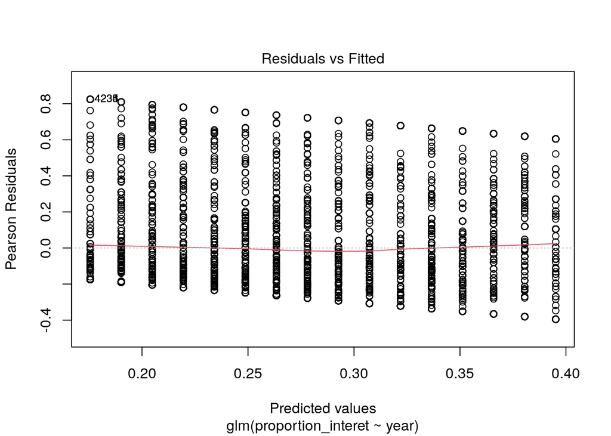

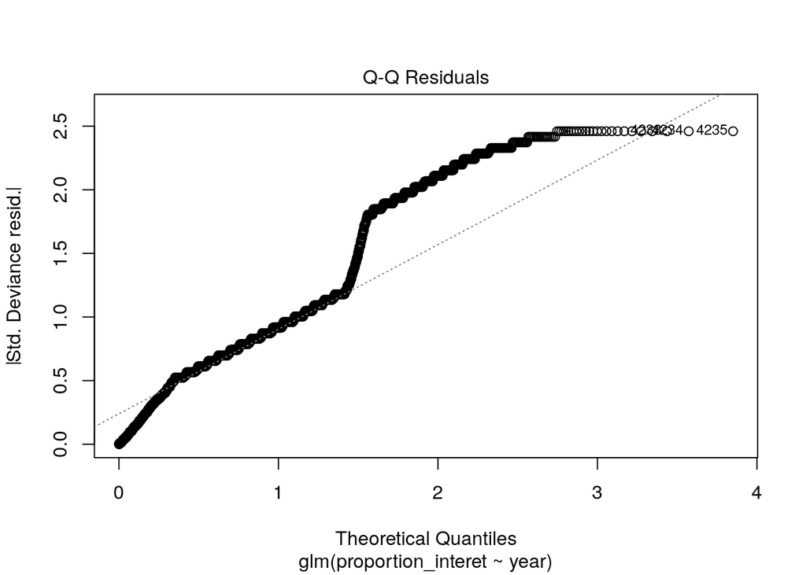

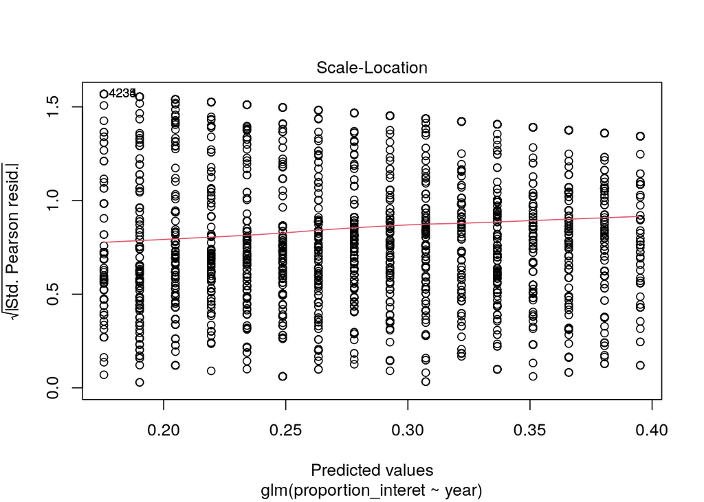

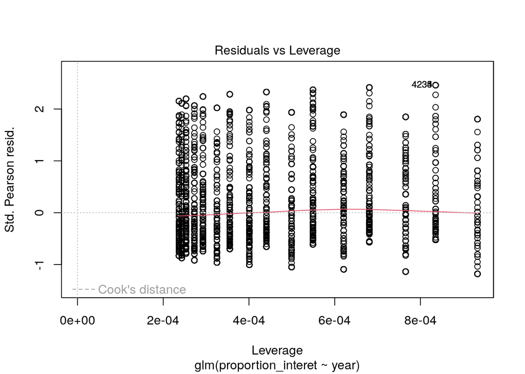

```r
plot(reg)
```

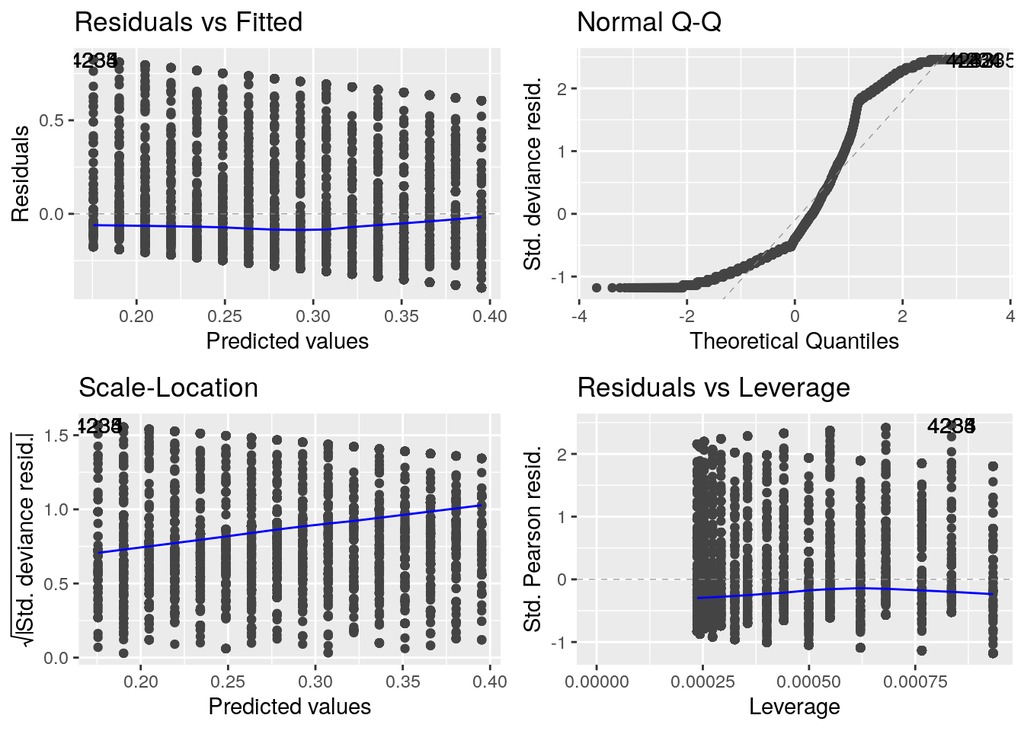

```r
autoplot(reg)
```

Ici, l’année est significative. Les résidus ne sont pas très aléatoire -> Encore des choses a expliquer. On a un QQ-plot pas top. Les résidus ne sont pas du bruit blanc gaussien.

Pas de données qui sont leviers.

```r
reg <- glm(data = bdd_reg,
           proportion_interet ~ year+famille_paysage_max)
summary(reg)
```

```
##
## Call:
## glm(formula = proportion_interet ~ year + famille_paysage_max,
##     data = bdd_reg)
##
## Coefficients:
##                                                          Estimate Std. Error
## (Intercept)                                             31.207802   2.205844
## year                                                    -0.015287   0.001092
## famille_paysage_maxPaysage boise et de bosquets         -0.180724   0.102664
## famille_paysage_maxPaysage cultive avec talus           -0.004825   0.102465
## famille_paysage_maxPaysage cultive e ragosses           -0.104675   0.102214
## famille_paysage_maxPaysage de bocage dense sur collines -0.192717   0.102756
## famille_paysage_maxPaysage de bocage e maille elargie   -0.127529   0.102703
## famille_paysage_maxPaysage de cultures legumieres        0.168598   0.103952
## famille_paysage_maxPaysage de littoral urbanise          0.025078   0.102755
##                                                         t value Pr(>|t|)
## (Intercept)                                              14.148   <2e-16 ***
## year                                                    -13.994   <2e-16 ***
## famille_paysage_maxPaysage boise et de bosquets          -1.760   0.0784 .
## famille_paysage_maxPaysage cultive avec talus            -0.047   0.9624
## famille_paysage_maxPaysage cultive e ragosses            -1.024   0.3059
## famille_paysage_maxPaysage de bocage dense sur collines  -1.875   0.0608 .
## famille_paysage_maxPaysage de bocage e maille elargie    -1.242   0.2144
## famille_paysage_maxPaysage de cultures legumieres         1.622   0.1049
## famille_paysage_maxPaysage de littoral urbanise           0.244   0.8072
## ---
## Signif. codes:  0 '***' 0.001 '**' 0.01 '*' 0.05 '.' 0.1 ' ' 1
##
## (Dispersion parameter for gaussian family taken to be 0.1035606)
##
##     Null deviance: 494.50  on 4234  degrees of freedom
## Residual deviance: 437.65  on 4226  degrees of freedom
## AIC: 2426.1
##
## Number of Fisher Scoring iterations: 2
```

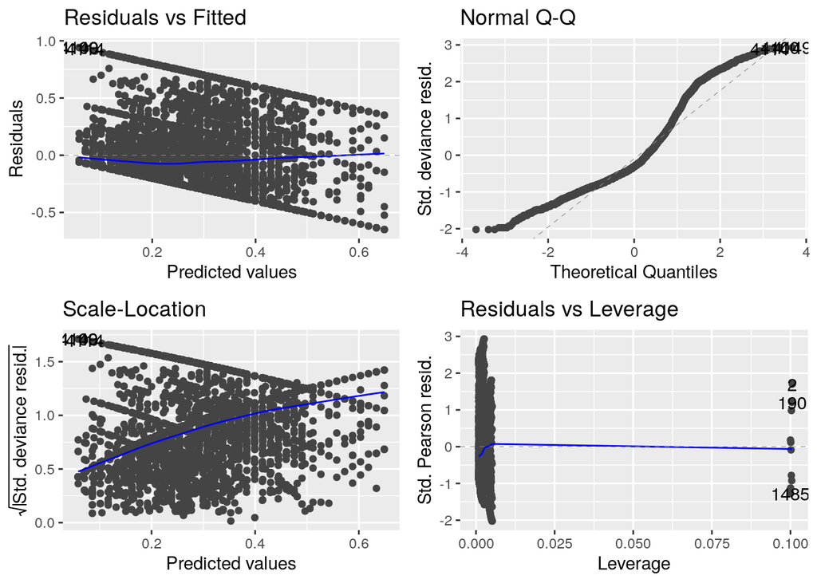

```r
autoplot(reg)
```

La famille de paysage n’est pas significatif, mais AIC plus faible, donc ca reste intéressant d’ajouter la famille de paysage dans l’analyse.

Meilleur QQ-plot, et residus.

Certains individus sont atypiques, ils ont un effet levier important. Cependant, ils ont une distance de Cook assez faible/normal, donc on n’a pas a s’inquiéter. Ils concernent des sites de Paysage associe a la presence d’eau.

```r
reg <- glm(data = bdd_reg,
           proportion_interet ~ year*famille_paysage_max)
summary(reg)
```

```
##
## Call:
## glm(formula = proportion_interet ~ year * famille_paysage_max,
##     data = bdd_reg)
##
## Coefficients:
##                                                                Estimate
## (Intercept)                                                   136.86134
## year                                                           -0.06767
## famille_paysage_maxPaysage boise et de bosquets              -115.17443
## famille_paysage_maxPaysage cultive avec talus                -112.41296
## famille_paysage_maxPaysage cultive e ragosses                 -92.28282
## famille_paysage_maxPaysage de bocage dense sur collines      -106.05040
## famille_paysage_maxPaysage de bocage e maille elargie        -102.22879
## famille_paysage_maxPaysage de cultures legumieres            -130.90804
## famille_paysage_maxPaysage de littoral urbanise              -110.90470
## year:famille_paysage_maxPaysage boise et de bosquets            0.05701
## year:famille_paysage_maxPaysage cultive avec talus              0.05573
## year:famille_paysage_maxPaysage cultive e ragosses              0.04570
## year:famille_paysage_maxPaysage de bocage dense sur collines    0.05248
## year:famille_paysage_maxPaysage de bocage e maille elargie      0.05062
## year:famille_paysage_maxPaysage de cultures legumieres          0.06498
## year:famille_paysage_maxPaysage de littoral urbanise            0.05499
##                                                              Std. Error t value
## (Intercept)                                                    45.68565   2.996
## year                                                            0.02265  -2.988
## famille_paysage_maxPaysage boise et de bosquets                46.07094  -2.500
## famille_paysage_maxPaysage cultive avec talus                  46.00086  -2.444
## famille_paysage_maxPaysage cultive e ragosses                  45.87905  -2.011
## famille_paysage_maxPaysage de bocage dense sur collines        46.11096  -2.300
## famille_paysage_maxPaysage de bocage e maille elargie          46.10077  -2.218
## famille_paysage_maxPaysage de cultures legumieres              46.69391  -2.804
## famille_paysage_maxPaysage de littoral urbanise                46.13227  -2.404
## year:famille_paysage_maxPaysage boise et de bosquets            0.02284   2.496
## year:famille_paysage_maxPaysage cultive avec talus              0.02281   2.444
## year:famille_paysage_maxPaysage cultive e ragosses              0.02274   2.009
## year:famille_paysage_maxPaysage de bocage dense sur collines    0.02286   2.296
## year:famille_paysage_maxPaysage de bocage e maille elargie      0.02285   2.215
## year:famille_paysage_maxPaysage de cultures legumieres          0.02315   2.807
## year:famille_paysage_maxPaysage de littoral urbanise            0.02287   2.405
```

[output cut: 12 more lines]

```
## year:famille_paysage_maxPaysage cultive e ragosses            0.04457 *
## year:famille_paysage_maxPaysage de bocage dense sur collines  0.02174 *
## year:famille_paysage_maxPaysage de bocage e maille elargie    0.02683 *
## year:famille_paysage_maxPaysage de cultures legumieres        0.00502 **
## year:famille_paysage_maxPaysage de littoral urbanise          0.01623 *
## ---
## Signif. codes:  0 '***' 0.001 '**' 0.01 '*' 0.05 '.' 0.1 ' ' 1
##
## (Dispersion parameter for gaussian family taken to be 0.1030582)
##
##     Null deviance: 494.5  on 4234  degrees of freedom
## Residual deviance: 434.8  on 4219  degrees of freedom
## AIC: 2412.5
##
## Number of Fisher Scoring iterations: 2
```

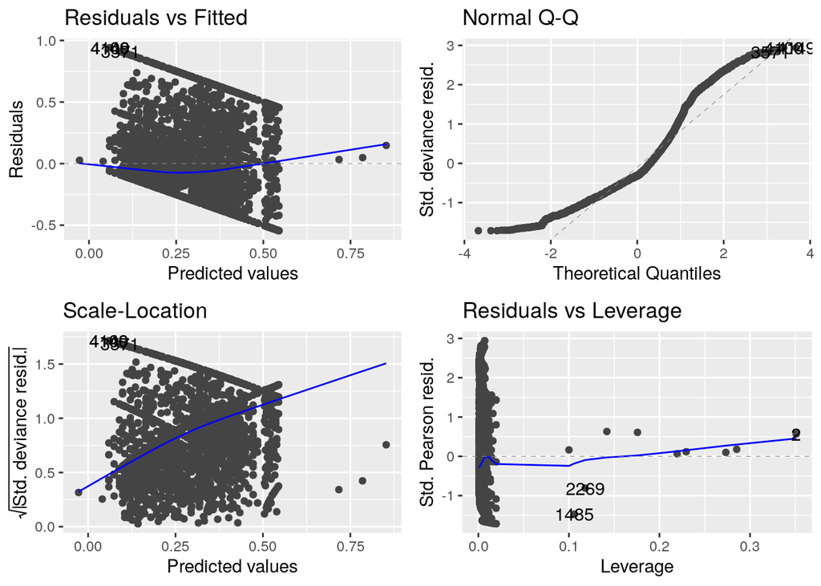

```r
autoplot(reg)
```

Ici tout est significatif, et on a un AIC plus faible. On a bien fait d’ajouter l’interaction entre l’annee et la famille de paysage.

On ne remarque pas de structure tres tres forte des residus, mais plus que la regression precedente. L’individu 2 a un tres fort effet levier ainsi que quelques autres individus.

#### 4 Year en variable qualitative:

```r
bdd_reg_yearquali <- bdd_reg %>%
  mutate(year = as.factor(year))

reg <- glm(data = bdd_reg_yearquali,
           proportion_interet ~ year)
summary(reg)
```

```
##
## Call:
## glm(formula = proportion_interet ~ year, data = bdd_reg_yearquali)
##
## Coefficients:
##              Estimate Std. Error t value Pr(>|t|)
## (Intercept)  0.353410   0.024544  14.399  < 2e-16 ***
## year2011     0.075446   0.032224   2.341 0.019264 *
## year2012     0.066096   0.031873   2.074 0.038164 *
## year2013     0.003379   0.032386   0.104 0.916895
## year2014    -0.025387   0.031778  -0.799 0.424408
## year2015    -0.065243   0.032670  -1.997 0.045889 *
## year2016    -0.078880   0.032386  -2.436 0.014906 *
## year2017    -0.090902   0.032277  -2.816 0.004881 **
## year2018    -0.083086   0.031709  -2.620 0.008818 **
## year2019    -0.095431   0.031825  -2.999 0.002728 **
## year2020    -0.106402   0.031619  -3.365 0.000772 ***
## year2021    -0.141958   0.031240  -4.544 5.67e-06 ***
## year2022    -0.097881   0.031575  -3.100 0.001948 **
## year2023    -0.147562   0.031509  -4.683 2.91e-06 ***
## year2024    -0.154685   0.031531  -4.906 9.65e-07 ***
## year2025    -0.163098   0.032198  -5.065 4.25e-07 ***
## ---
## Signif. codes:  0 '***' 0.001 '**' 0.01 '*' 0.05 '.' 0.1 ' ' 1
##
## (Dispersion parameter for gaussian family taken to be 0.112049)
##
##     Null deviance: 494.50  on 4234  degrees of freedom
## Residual deviance: 472.73  on 4219  degrees of freedom
## AIC: 2766.7
##
## Number of Fisher Scoring iterations: 2
```

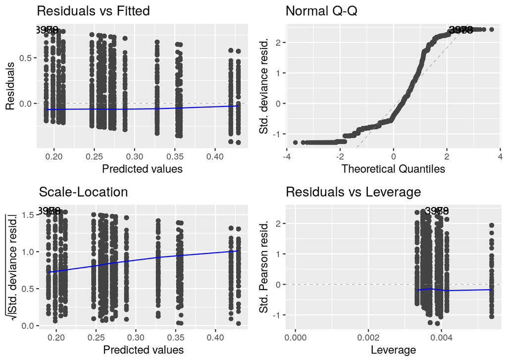

```r
autoplot(reg)
```

```r
reg <- glm(data = bdd_reg_yearquali,
           proportion_interet ~ year+famille_paysage_max)
summary(reg)
```

```
##
## Call:
## glm(formula = proportion_interet ~ year + famille_paysage_max,
##     data = bdd_reg_yearquali)
##
## Coefficients:
##                                                          Estimate Std. Error
## (Intercept)                                              0.438317   0.103871
## year2011                                                 0.079815   0.030908
## year2012                                                 0.068965   0.030571
## year2013                                                -0.001420   0.031073
## year2014                                                -0.026644   0.030487
## year2015                                                -0.070542   0.031344
## year2016                                                -0.084718   0.031066
## year2017                                                -0.101891   0.030962
## year2018                                                -0.089736   0.030421
## year2019                                                -0.100875   0.030526
## year2020                                                -0.116401   0.030331
## year2021                                                -0.146753   0.029968
## year2022                                                -0.107304   0.030292
## year2023                                                -0.153934   0.030224
## year2024                                                -0.164137   0.030250
## year2025                                                -0.167883   0.030894
## famille_paysage_maxPaysage boise et de bosquets         -0.180281   0.102489
## famille_paysage_maxPaysage cultive avec talus           -0.003919   0.102295
## famille_paysage_maxPaysage cultive e ragosses           -0.105356   0.102040
## famille_paysage_maxPaysage de bocage dense sur collines -0.193031   0.102587
## famille_paysage_maxPaysage de bocage e maille elargie   -0.126194   0.102521
## famille_paysage_maxPaysage de cultures legumieres        0.170669   0.103772
## famille_paysage_maxPaysage de littoral urbanise          0.026531   0.102582
##                                                         t value Pr(>|t|)
## (Intercept)                                               4.220 2.50e-05 ***
## year2011                                                  2.582 0.009846 **
## year2012                                                  2.256 0.024126 *
## year2013                                                 -0.046 0.963547
## year2014                                                 -0.874 0.382197
## year2015                                                 -2.251 0.024463 *
## year2016                                                 -2.727 0.006416 **
## year2017                                                 -3.291 0.001007 **
## year2018                                                 -2.950 0.003197 **
```

[output cut: 9 more lines]

```
## famille_paysage_maxPaysage cultive e ragosses            -1.032 0.301901
## famille_paysage_maxPaysage de bocage dense sur collines  -1.882 0.059956 .
## famille_paysage_maxPaysage de bocage e maille elargie    -1.231 0.218426
## famille_paysage_maxPaysage de cultures legumieres         1.645 0.100115
## famille_paysage_maxPaysage de littoral urbanise           0.259 0.795933
## ---
## Signif. codes:  0 '***' 0.001 '**' 0.01 '*' 0.05 '.' 0.1 ' ' 1
##
## (Dispersion parameter for gaussian family taken to be 0.1030623)
##
##     Null deviance: 494.5  on 4234  degrees of freedom
## Residual deviance: 434.1  on 4212  degrees of freedom
## AIC: 2419.6
##
## Number of Fisher Scoring iterations: 2
```

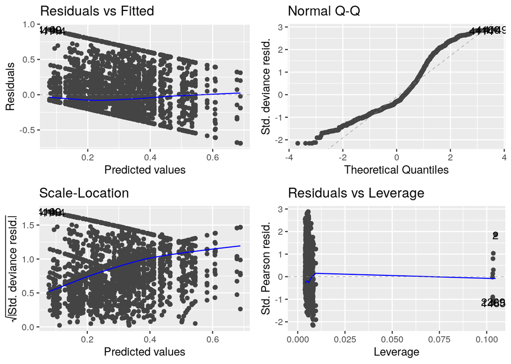

```r
autoplot(reg)
```

A continuer: year^2, clusters

```r
reg1 <- glm(data = bdd_reg,
           proportion_interet ~ year + famille_paysage_max:year)
reg2 <- glm(data = bdd_reg,
           proportion_interet ~ I(year^2) + year + famille_paysage_max:year)

AIC(reg1); AIC(reg2)
```

```
## [1] 2425.94
```

```
## [1] 2420.425
```

```r
BIC(reg1); BIC(reg2)
```

```
## [1] 2489.451
```

```
## [1] 2490.288
```

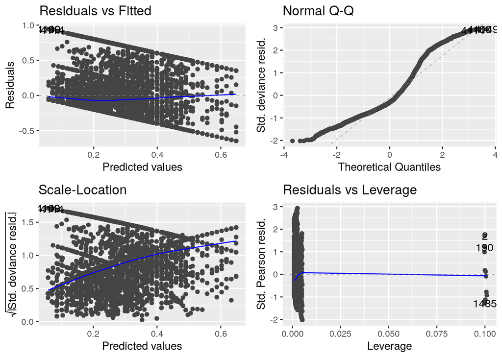

```r
# Niveau AIC/BIC y'a pas une grosse difference. BIC prefere moins de var. et AIC l'inverse donc logique, mais pas de preference majeure.

autoplot(reg1)
```

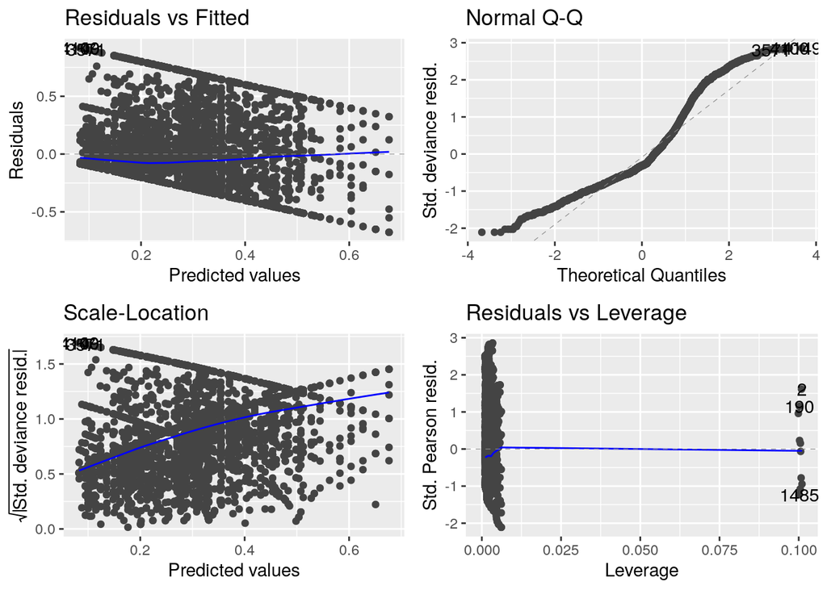

```r
autoplot(reg2)
```

On ne dirait pas qu’il y a qqe chose de différent entre ces deux modèles.

#### 5 0 Inflated Model?

```r
# #library(glmmTMB)
# glmmTMB(data = bdd_reg,
#         proportion_interest ~ year,
#         family = "nbinom2"
#         )
```